# Overview

FW8051 Statistics for Ecologists

# Learning Objectives and steps we will take to meet them.

*Demonstrate an ability to implement a variety of statistical models and methods in frequentist and Bayesian frameworks*

Bring a computer every day to class!

*Demonstrate an understanding of a range of advanced statistical modeling techniques and an ability to choose an appropriate method depending on characteristics of the data.*

Will consider models for:

- Normal (i.e., Gaussian) data with constant variance (linear regression)
- Non-linear predictor-response relationships
- Data with non-constant variance (generalized least squares)
- Count and binary data (generalized linear models)
- Correlated data (mixed models, generalized estimating equations, cluster-level bootstrap).

*Demonstrate “model literacy” – be able to describe a variety of statistical models and their assumptions using equations and text and match parameters in these equations to estimates in computer output.*

$$Y_i \sim N(\mu_i, \sigma^2)$$

$$\mu_i = \beta_0 + \beta_1Proprtion.Black_i$$

```
Call:
lm(formula = age ~ proportion.black, data = LionNoses)

Residuals:
    Min      1Q  Median      3Q     Max
-2.5449 -1.1117 -0.5285  0.9635  4.3421

Coefficients:
                 Estimate Std. Error t value Pr(>|t|)
(Intercept)        0.8790     0.5688   1.545    0.133
proportion.black  10.6471     1.5095   7.053 7.68e-08 ***
---
Signif. codes:  0 '***' 0.001 '**' 0.01 '*' 0.05 '.' 0.1 ' ' 1

Residual standard error: 1.669 on 30 degrees of freedom
Multiple R-squared:  0.6238,    Adjusted R-squared:  0.6113
F-statistic: 49.75 on 1 and 30 DF,  p-value: 7.677e-08
```

We will work on this nearly every day in class!

*Conduct research using a workflow that maximizes ‘reproducibility’ of your work.*

- Projects in Rstudio
- rmarkdown/quarto, knitr
- Project/file management

Homework and in-class assignments will give you experience with tools in R/Rstudio for reproducible research

[figure not shown]

*Gain an appreciation for challenges associated with selecting among competing models and performing multi-model inference.*

- We will *briefly* cover some popular model-building strategies
- We will consider directed acyclical graphs and their implications for choosing appropriate models

## Self and Peer Evaluations

I use a combination of self- and peer-evaluations to aid in grading homework assignments.

- helps me spend my time efficiently
- provides an opportunity to teach and learn from your peers

To make this work, it is important that you turn in assignments on time, so please plan ahead if you will be away or have a busy stretch.

Please let me know if you have extenuating circumstances that prevent you from being able to turn in an assignment on time.

## Assessments

1. Complete exercises in the Stats4EcologistsByEcologists book.
2. Submit your answers in the form of a reproducible (pdf, or word) document created using R/Rstudio.
3. Self assessment: view the answer key and then note: a) any areas where your understanding was lacking prior to viewing the answer key; and b) whether or not any aspects of the problem (or solution) remain unclear after having viewed the answer key.
4. Peer assessment: review your peer’s solution for completeness and accuracy and provide comments to help the student improve their understanding. If your peer clearly understood and fully completed the original assignment, please note this in your peer review.
5. Read over your comments on your assignment provided by your peer (and by me).

## Grading of Homework assignments

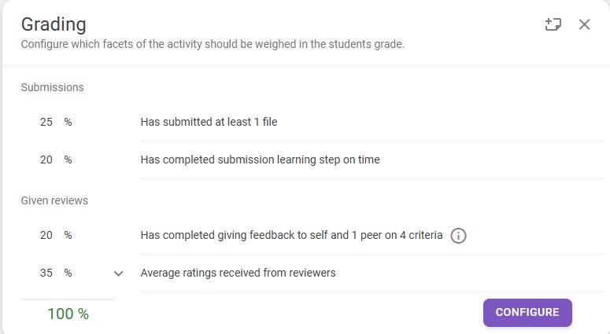

## Peer Assessment

Comments from previous year’s course evaluations

- I like the self and peer assessments. It helps to be forced to review answers and process, otherwise I would just move to the next 10 things I have to work on.
- Homework grading format is awesome: by evaluating ourselves and our peer before instructor sees our work, we are able to better understand mistakes that we made and /or others made and subsequently offer suggestions in a “learning by teaching” fashion.
- I found the peer assessments to be highly valuable. The code we were exposed to throughout the course plus looking at more variations within the peer assessments has brought my level of understanding up significantly.

## Grading

- Homework assignments (45%), includes self and peer assessments
- Quizzes (~7) (15%)
- Midterm exam (20%)
- Final exam (20%)

S/N students will be required to complete all homework assignments and self and peer reviews, but will not have to take the final exam, quizzes. There is a chance that part of the final exam will involve creating (and solving) your own problem set.